# Comparison of all Four

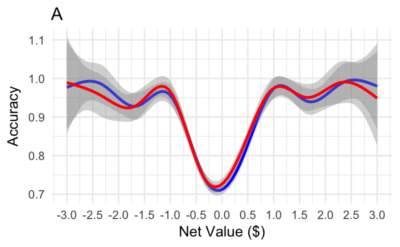

`r`r

#geom_point(shape=1) + # Use hollow circles geom_smooth() # Add a loess smoothed fit curve with confidence region

```
geom_smooth: na.rm = FALSE
stat_smooth: na.rm = FALSE, method = auto, formula = y ~ x, se = TRUE
position_identity
```

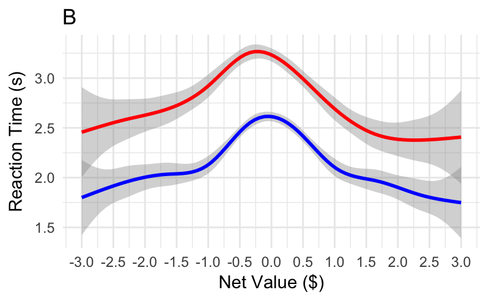

`r`r #geom_point(shape=1) + # Use hollow circles geom_smooth() # Add a loess smoothed fit curve with confidence region

```
geom_smooth: na.rm = FALSE
stat_smooth: na.rm = FALSE, method = auto, formula = y ~ x, se = TRUE
position_identity
```

`r`r corr.test()

## SUMMARY STATS

`r`r library(psych) tapply(df_mults$rt, df_mults$id, mean)

describeBy(df_mults$rt, df_mults$id)

`r`r # Figure out histogram bin size, based on equal numbers of observations library(Hmisc) # cut2

S_M$valBin <- as.numeric(cut2(S_M$summedVal, g=15)) table(S_M$valBin)

S_M$valBinAmt <- cut2(S_M$summedVal, g=15) table(S_M$valBinAmt)